# Fitting model 39

Load all important libraries

# Read model

## parameters occuring in the ode, but not in “pars”

## parameters occuring in “pars”, but not in the ode

## Odemodel and predicition function

```
## The following local files were dynamically loaded: odemodel.so, odemodel_s.so
```

## Data

Read and transform to dMod-style

## Prepare conditions

### Plot

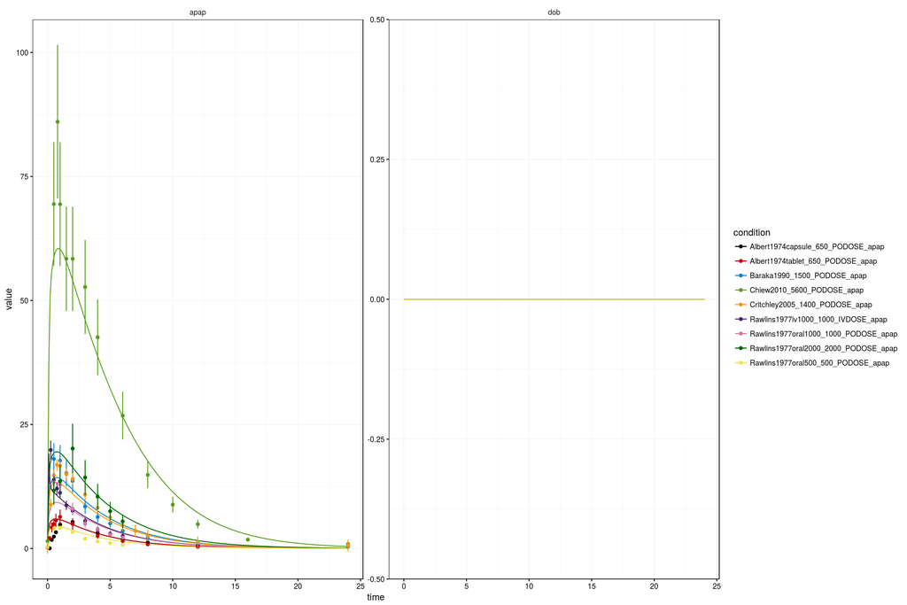

## Fit

```
##   index    value converged iterations   KA_APAP APAPD_HLM_CL APAPD_KM_APAP
## 1    19 509.4747      TRUE         31 0.3503171    0.5388579     -1.384625
## 2     9 509.4748      TRUE         38 0.3503393    0.5388608     -1.384629
## 3    11 509.4748      TRUE         31 0.3503426    0.5388501     -1.384646
## 4    20 509.4749      TRUE         36 0.3514042    0.5407323     -1.381703
## 5     7 509.4751      TRUE         29 0.3504585    0.5389560     -1.384497
## 6    14 509.4751      TRUE         34 0.3504770    0.5388813     -1.384605
## 7     5 509.4751      TRUE         29 0.3506080    0.5390719     -1.384343
```

### Plot the best fit

```
##  APAPD_HLM_CL:  0.538857946696742
## APAPD_KM_APAP: -1.38462522336027
##       KA_APAP:  0.350317122853469
```

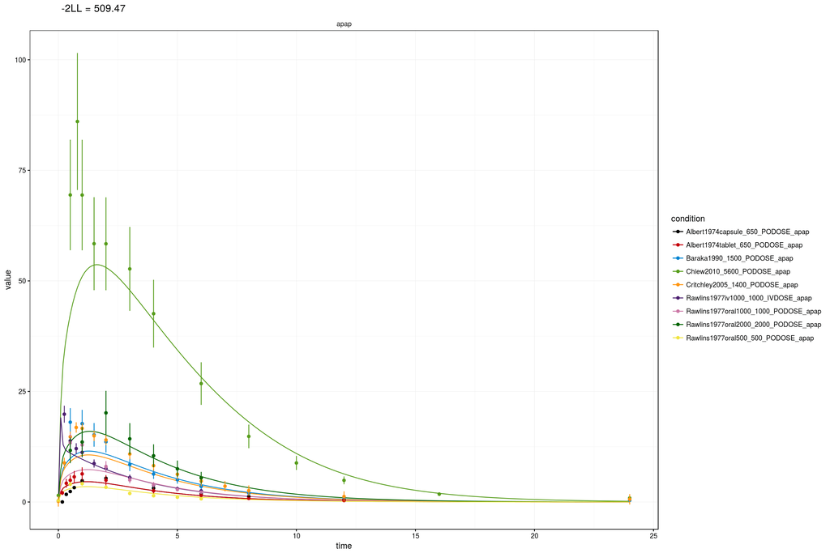

To me it looks as if the data of Albert1974 capsule is shifted to the right, since its rise starts later. In the end this makes sense, because the capsule first needs to burst. The question is, how do we deal with this?

# Allow for different Aborption speeds

To me it looks as if the data of Albert1974 capsule is shifted to the right, since its rise starts later. In the end this makes sense, because the capsule first needs to burst. The question is, how do we deal with this?

In a first step, let’s assume all studies have a different absorption rate Ka_apap.

## Data

Read and transform to dMod-style

## Fit

Show which fits converged

```
##   index    value converged iterations APAPD_HLM_CL APAPD_KM_APAP
## 1    17 319.7358      TRUE         35    0.6113331     -1.243796
## 2     9 319.7486      TRUE         41    0.6112289     -1.243809
## 3    19 320.2014      TRUE         38    0.6199807     -1.234209
## 4    11 322.6492      TRUE         36    0.6843548     -1.137040
## 5    13 326.8771      TRUE         39    0.6717317     -1.166432
## 6     7 349.8925      TRUE         45    0.6712814     -1.178299
## 7    14 439.5646      TRUE         40    0.5718584     -1.305956
##   KA_APAP_ALBERT1974_CAPSULE KA_APAP_ALBERT1974_TABLET KA_APAP_BARAKA1990_
## 1                 -0.2616161                 0.2923910           15.703545
## 2                 -0.2616352                 0.2924122            5.021153
## 3                 -0.2616226                 0.2926314            7.959389
## 4                 -0.2666005                 0.3008799            1.796318
## 5                 -0.2636659                 0.2965621            6.675802
## 6                 -0.2614927                 0.2937436            6.999563
## 7                 -0.2580787                -3.2011259            7.118990
##   KA_APAP_CHIEW2010_ KA_APAP_CRITCHLEY2005_ KA_APAP_RAWLINS1977_
## 1           1.510214              0.9357131            0.9775650
## 2           1.519606              0.9356890            0.9775824
## 3          20.077570              0.9361256            0.9788458
## 4           1.514898              0.9351907            2.8501749
## 5           1.525727              0.9371025           50.8894632
## 6           2.410496             26.1603182            0.9842399
## 7           1.512883              0.9364660            0.9577569
```

### Plot the best fit

Making the Ka_apap parameters condition specific improves the fit.

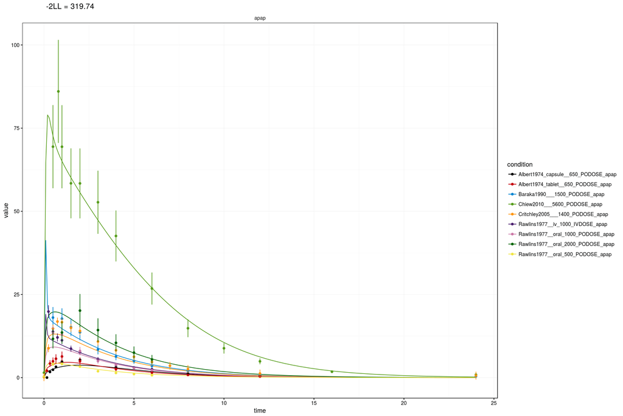

# Allow for different doses

It seems as if the specified dosing is too low in many cases. Therefore, we should try to adjust the dosing. This might help to account for the different bodyweights, different absorption efficiencies, etc…

## Prediction function with sensitivites also for doses

## Data

Read and transform to dMod-style

## Fit

Fit with condition specific Ka_apap and Dosing

Apply a l2 prior on the dose.

```
##   index    value converged iterations APAPD_HLM_CL APAPD_KM_APAP
## 1    90 235.5104      TRUE         32    0.7999551     -1.186865
## 2    50 235.5113      TRUE         39    0.7999612     -1.186833
## 3    43 235.5115      TRUE         51    0.8005507     -1.186082
## 4    26 235.5123      TRUE         44    0.7998911     -1.186939
## 5    80 235.5339      TRUE         46    0.7992047     -1.189038
## 6    52 235.5340      TRUE         36    0.8003034     -1.187627
## 7     3 235.5347      TRUE         51    0.7994131     -1.188782
##   KA_APAP_ALBERT1974_CAPSULE DOSE_ALBERT1974_650 KA_APAP_ALBERT1974_TABLET
## 1                 -0.4560710            6.698112                 0.1076997
## 2                 -0.4560586            6.698092                 0.1077142
## 3                 -0.4558646            6.697954                 0.1078830
## 4                 -0.4560741            6.698115                 0.1076942
## 5                 -0.4568731            6.699222                 0.1065771
## 6                 -0.4567580            6.699042                 0.1067890
```

[output cut: 33 more lines]

### Plot des erstbesten Fits

Zuerst die Parameter

```
##               APAPD_HLM_CL:  2.22544095665242
##              APAPD_KM_APAP:  0.305176357897327
##        DOSE_ALBERT1974_650:  810.873336043976
##       DOSE_BARAKA1990_1500:  1729.56458919945
##        DOSE_CHIEW2010_5600:  6272.46577138278
##    DOSE_CRITCHLEY2005_1400:  1995.41810294259
##      DOSE_RAWLINS1977_1000:  1158.15314329815
##      DOSE_RAWLINS1977_2000:  1894.84936412998
##       DOSE_RAWLINS1977_500:  481.607216212635
## KA_APAP_ALBERT1974_CAPSULE:  0.633768849778204
##  KA_APAP_ALBERT1974_TABLET:  1.11371322819165
##        KA_APAP_BARAKA1990_:  2917.97766989803
##         KA_APAP_CHIEW2010_:  3.12670928314237
##     KA_APAP_CRITCHLEY2005_:  1.56380981428631
##       KA_APAP_RAWLINS1977_:  2.62837516729225
```

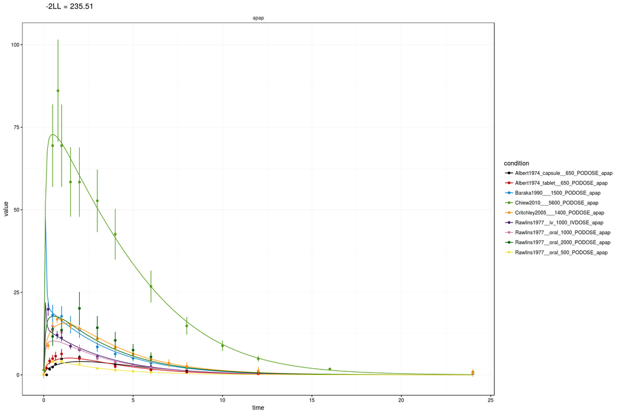

### Plot des zweitbesten Fits

Unterschied in Baraka 1990

[output not shown]

[figure not shown]